# **Part 1: Explanatory Data Analysis**

```python
import pandas as pd

# Load the dataset
file_path = "https://raw.githubusercontent.com/reyar/Statsomat/master/cacao.csv"
data = pd.read_csv(file_path)

# Display the table of descriptive statistics
descriptive_stats = data.describe()
descriptive_stats
```

|  | ant_exclusion | stem_diameter | height | canopy | dw_healthy | dw_infect | dw_total | fw_pulb | fw_seeds | fw_total | ab_fl_op | ab_fl_cl | ab_fl |
| --- | --- | --- | --- | --- | --- | --- | --- | --- | --- | --- | --- | --- | --- |
| count | 120.000000 | 120.000000 | 120.00000 | 120.000000 | 120.000000 | 120.000000 | 120.00000 | 120.000000 | 120.000000 | 120.000000 | 120.000000 | 120.000000 | 120.000000 |
| mean | 0.500000 | 27.096563 | 293.00000 | 0.329775 | 1054.783333 | 149.550000 | 1203.52500 | 16239.708333 | 5404.450000 | 21617.558333 | 1550.133333 | 3910.916667 | 5452.608333 |
| std | 0.502096 | 5.305994 | 34.60555 | 0.173708 | 750.210494 | 146.952622 | 824.98166 | 10796.705994 | 3541.421449 | 14236.181067 | 904.836435 | 2230.832044 | 3106.131029 |
| min | 0.000000 | 15.737500 | 223.75000 | 0.015000 | 0.000000 | 0.000000 | 0.00000 | 0.000000 | 0.000000 | 0.000000 | 241.000000 | 741.000000 | 1114.000000 |
| 25% | 0.000000 | 23.375000 | 270.37500 | 0.181250 | 447.250000 | 46.750000 | 573.25000 | 8083.500000 | 2824.250000 | 11107.250000 | 905.250000 | 2277.500000 | 3178.250000 |
| 50% | 0.500000 | 26.712500 | 287.87500 | 0.344167 | 939.500000 | 116.000000 | 1135.00000 | 14767.000000 | 4983.000000 | 19292.000000 | 1360.000000 | 3440.500000 | 4798.000000 |
| 75% | 1.000000 | 30.365625 | 313.18750 | 0.449167 | 1536.000000 | 216.500000 | 1717.50000 | 21869.250000 | 7544.500000 | 29008.250000 | 2018.750000 | 5053.250000 | 7006.750000 |
| max | 1.000000 | 46.600000 | 399.50000 | 0.708333 | 3045.000000 | 920.000000 | 3500.00000 | 60787.000000 | 17025.000000 | 77812.000000 | 4369.000000 | 12469.000000 | 16501.000000 |

Explanation:

- **Count**: Number of non-missing values for each variable.
- **Mean**: Average value of each variable.
- **Std**: Standard deviation, indicating the dispersion of the data.
- **Min**: Minimum value observed.
- **25%**: 25th percentile, or first quartile.
- **50%**: 50th percentile, or median.
- **75%**: 75th percentile, or third quartile.
- **Max**: Maximum value observed.

Next, we will generate histograms for each variable to visualize their distributions.

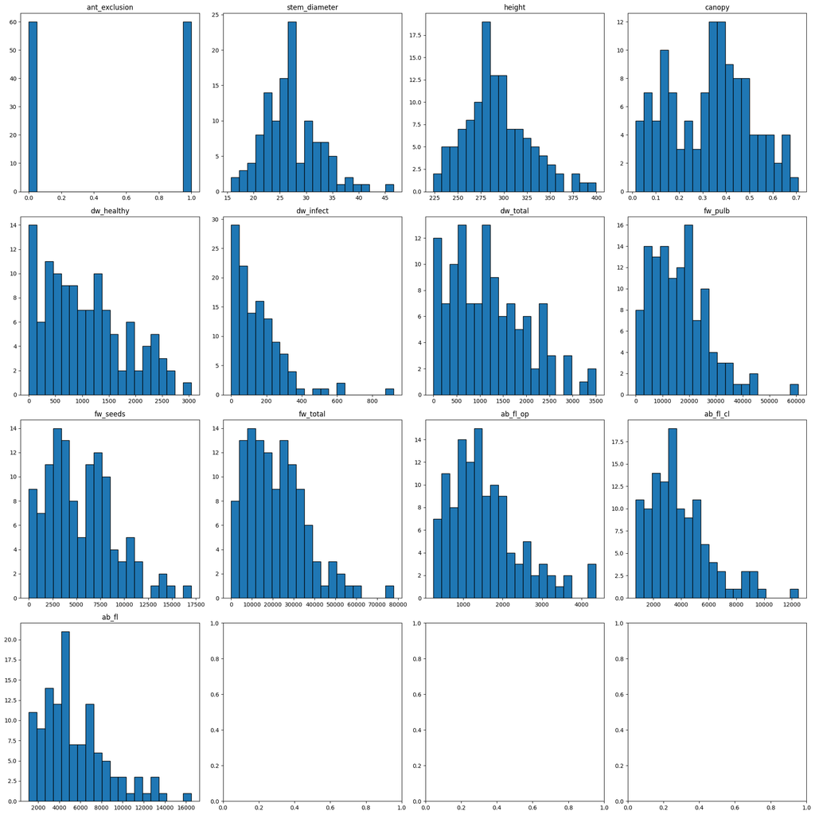

```python
import matplotlib.pyplot as plt

# List of variables
variables = data.columns

# Generate histograms
fig, axes = plt.subplots(nrows=4, ncols=4, figsize=(20, 20))
axes = axes.flatten()

for idx, var in enumerate(variables):
    axes[idx].hist(data[var].dropna(), bins=20, edgecolor='k')
    axes[idx].set_title(var)

plt.tight_layout()
plt.show()
```

Here are the histograms for each variable in the dataset.

**How to read a histogram:**

- A histogram displays the distribution of a dataset.
- The x-axis represents the bins or intervals of data.
- The y-axis represents the frequency or count of data points within each bin.
- The height of each bar shows how many data points fall into that specific bin.

Next, let's generate vertical boxplots for each variable.

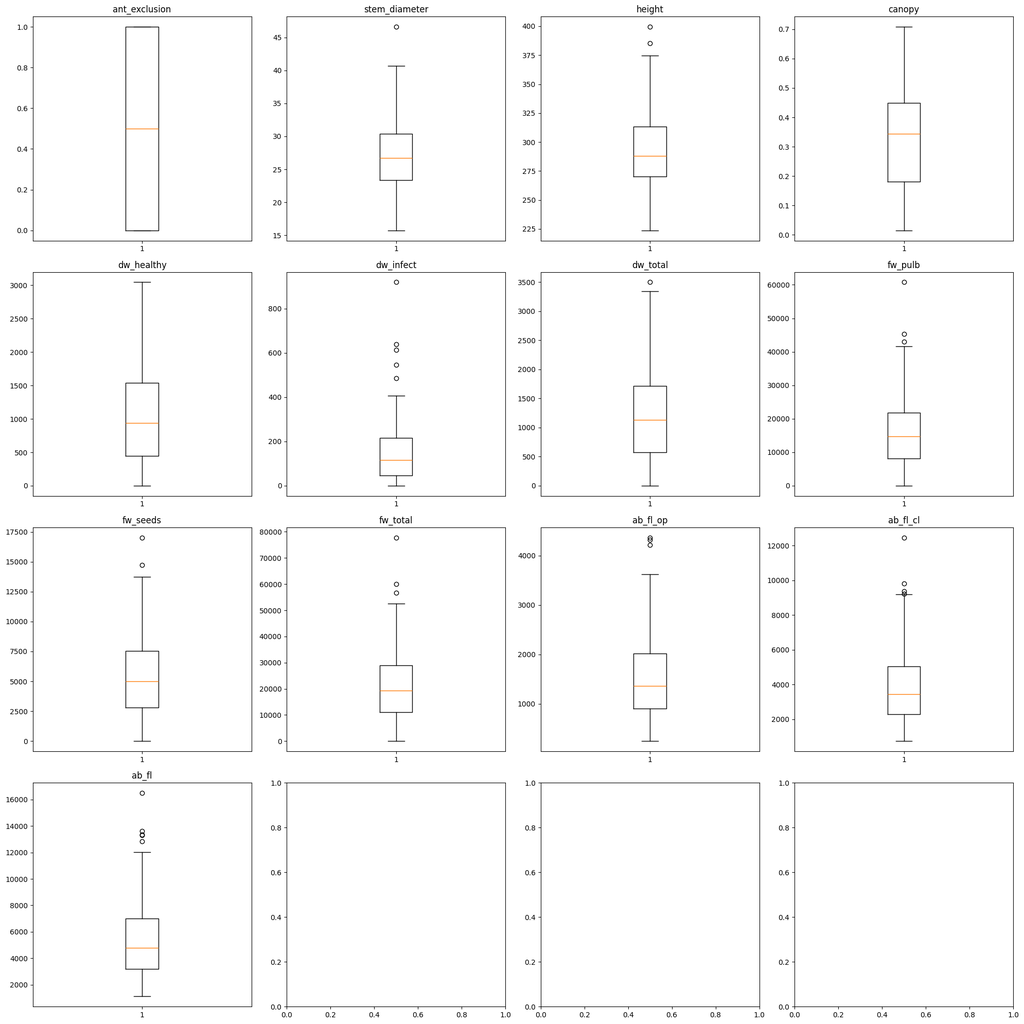

```python
# Generate vertical boxplots
fig, axes = plt.subplots(nrows=4, ncols=4, figsize=(20, 20))
axes = axes.flatten()

for idx, var in enumerate(variables):
    axes[idx].boxplot(data[var].dropna(), vert=True)
    axes[idx].set_title(var)

plt.tight_layout()
plt.show()
```

Here are the vertical boxplots for each variable in the dataset.

**How to read a boxplot:**

- A boxplot displays the distribution of data based on a five-number summary: minimum, first quartile (Q1), median, third quartile (Q3), and maximum.
- The box represents the interquartile range (IQR) between Q1 and Q3.
- The line inside the box shows the median.
- Whiskers extend from the box to the minimum and maximum values within 1.5 * IQR from Q1 and Q3.
- Points outside the whiskers are considered outliers.

Next, we will generate ECDF plots for each variable.

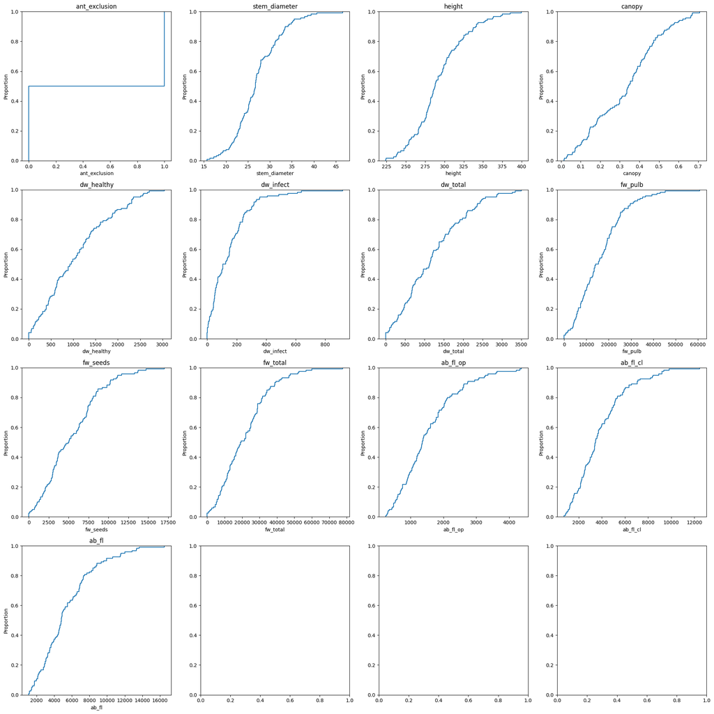

```python
import numpy as np
import seaborn as sns

# Generate ECDF plots
fig, axes = plt.subplots(nrows=4, ncols=4, figsize=(20, 20))
axes = axes.flatten()

for idx, var in enumerate(variables):
    sns.ecdfplot(data[var].dropna(), ax=axes[idx])
    axes[idx].set_title(var)

plt.tight_layout()
plt.show()
```

Here are the ECDF (Empirical Cumulative Distribution Function) plots for each variable in the dataset.

**How to read an ECDF plot:**

- An ECDF plot shows the proportion or count of observations falling below each value in the dataset.
- The x-axis represents the values of the variable.
- The y-axis represents the cumulative proportion of data points.
- Each step on the ECDF represents an individual data point.

Next, we will generate QQ plots for each variable.

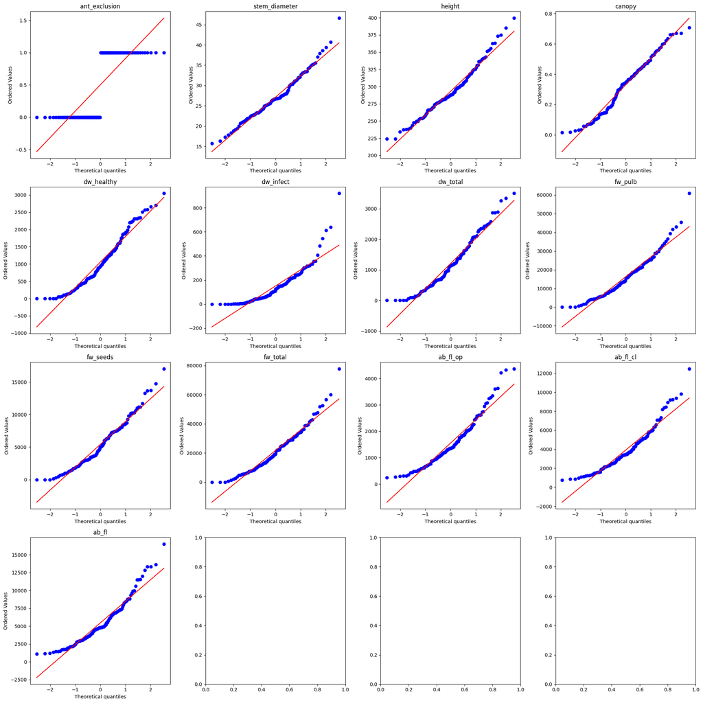

```python
import scipy.stats as stats

# Generate QQ plots
fig, axes = plt.subplots(nrows=4, ncols=4, figsize=(20, 20))
axes = axes.flatten()

for idx, var in enumerate(variables):
    stats.probplot(data[var].dropna(), dist="norm", plot=axes[idx])
    axes[idx].set_title(var)

plt.tight_layout()
plt.show()
```

Here are the QQ (Quantile-Quantile) plots for each variable in the dataset.

**How to read a QQ plot:**

- A QQ plot compares the distribution of a dataset to a theoretical distribution (typically normal).
- The x-axis represents the quantiles of the theoretical distribution.
- The y-axis represents the quantiles of the dataset.
- If the data follows the theoretical distribution, the points will lie along the reference line.
- Deviations from the line indicate departures from the theoretical distribution, such as skewness or heavy tails.

This concludes the visual exploration and explanation of the dataset's distributions and characteristics.

# **Part 2: Preparations for Regression Diagnostics**

### Assumptions of a Linear Regression Model

Linear regression models are based on several key assumptions that ensure the validity and reliability of the results.

Here are the main assumptions, detailed with their mathematical context:

1. **Linearity**: The relationship between the dependent variable $Y$ and the independent variables $X_i$ is linear.

This means the expected value of $Y$ given $X$ can be expressed as:

$Y = \beta_0 + \beta_1X_1 + \beta_2X_2 + \ldots + \beta_pX_p + \epsilon$

where $\beta_0$ is the intercept, $\beta_1, \beta_2, \ldots, \beta_p $ are the coefficients, and $\epsilon$ is the error term.

2. **Independence**: The residuals (errors) $\epsilon_i$ are independent.

This means there is no correlation between the residuals for any pair of observations.

3. **Homoscedasticity**: The variance of the residuals is constant for all levels of the independent variables.

Mathematically, this can be written as:

$\text{Var}(\epsilon_i) = \sigma^2 \quad \forall \, i$

where $\sigma^2$ is the constant variance of the residuals.

4. **Normality**: The residuals $\epsilon_i$ are normally distributed.

This is important for hypothesis testing and constructing confidence intervals.

The residuals should follow a normal distribution:

$\epsilon_i \sim N(0, \sigma^2)$

5. **No Multicollinearity**: The independent variables are not highly correlated with each other.

High correlation between independent variables makes it difficult to isolate the individual effect of each predictor.

### Further Learning Resources

- "Introduction to Linear Regression Analysis" by Douglas C. Montgomery, Elizabeth A. Peck, and G. Geoffrey Vining
- "Applied Linear Statistical Models" by John Neter, Michael H. Kutner, Christopher J. Nachtsheim, and William Li

### Building an OLS Regression Model

Using `stem_diameter` as the dependent variable and all other variables as independent variables, we can fit an Ordinary Least Squares (OLS) regression model.

Let's prepare the data and fit the model using Python:

```
import statsmodels.api as sm

# Defining the dependent and independent variables
X = data.drop(columns=['stem_diameter'])
y = data['stem_diameter']

# Adding a constant to the independent variables
X = sm.add_constant(X)

# Fitting the OLS regression model
model = sm.OLS(y, X).fit()
```

### Explanation of Regression Diagnostics

Regression diagnostics are a set of techniques used to evaluate the validity and quality of a regression model.

These diagnostics help in identifying potential problems with the model, such as violations of the underlying assumptions (linearity, independence, homoscedasticity, normality, and multicollinearity).

By examining various aspects of the model and the residuals, diagnostics can uncover issues like outliers, leverage points, and influential observations, which might affect the performance and interpretation of the regression results.

The goal of regression diagnostics is to ensure that the model is an accurate representation of the data and that the conclusions drawn from the model are valid.

# **Part 3: Regression Diagnostics**

### Outliers and Their Impact on Regression

**Outliers** are data points that significantly deviate from the other observations in the dataset.

In the context of regression, outliers can have a substantial impact on the estimation of the regression coefficients, the goodness-of-fit of the model, and the validity of statistical tests.

Mathematically, outliers can be identified by examining the residuals:

$r_i = y_i - \hat{y}_i$

where $r_i$ is the residual for the $i$-th observation, $ y_i$ is the observed value, and $ \hat{y}_i$ is the predicted value.

### Studentized Residuals

**Studentized Residuals** are the residuals divided by an estimate of their standard deviation.

They are used to detect outliers by standardizing the residuals to have a mean of zero and a variance of one.

The studentized residual $ t_i $ for the $i$-th observation is given by:

$t_i = \frac{r_i}{s_{(i)}}$

where $s_{(i)}$ is the standard deviation of the residuals when the $i$-th observation is excluded from the fitting process.

The standard deviation of the residuals $s_{(i)}$ can be calculated as:

$s_{(i)} = s \sqrt{1 - h_{ii}}$

where $s $ is the standard deviation of the residuals and $h_{ii}$ is the leverage of the $i$-th observation.

Outliers can be identified using a threshold for the studentized residuals.

Commonly, a threshold of 3 is used, meaning observations with studentized residuals greater than 3 in absolute value are considered outliers.

### Python Code to Identify Outliers Using Studentized Residuals and Plot

```
import numpy as np
import matplotlib.pyplot as plt
import statsmodels.api as sm

# Define the dependent and independent variables
X = data.drop(columns=['stem_diameter'])
y = data['stem_diameter']

# Add a constant to the independent variables
X = sm.add_constant(X)

# Fit the OLS regression model
model = sm.OLS(y, X).fit()

# Calculate studentized residuals
influence = model.get_influence()
studentized_residuals = influence.resid_studentized_internal

# Identify outliers
outliers = np.where(np.abs(studentized_residuals) > 3)[0]

# Plot studentized residuals vs. index
plt.figure(figsize=(10, 6))
plt.scatter(range(len(studentized_residuals)), studentized_residuals, edgecolor='k', facecolors='none')
plt.axhline(y=3, color='r', linestyle='--')
plt.axhline(y=-3, color='r', linestyle='--')
plt.xlabel('Index')
plt.ylabel('Studentized Residuals')
plt.title('Studentized Residuals vs. Index')
plt.show()

outliers
```

Let's execute the above code to identify and visualize the outliers.

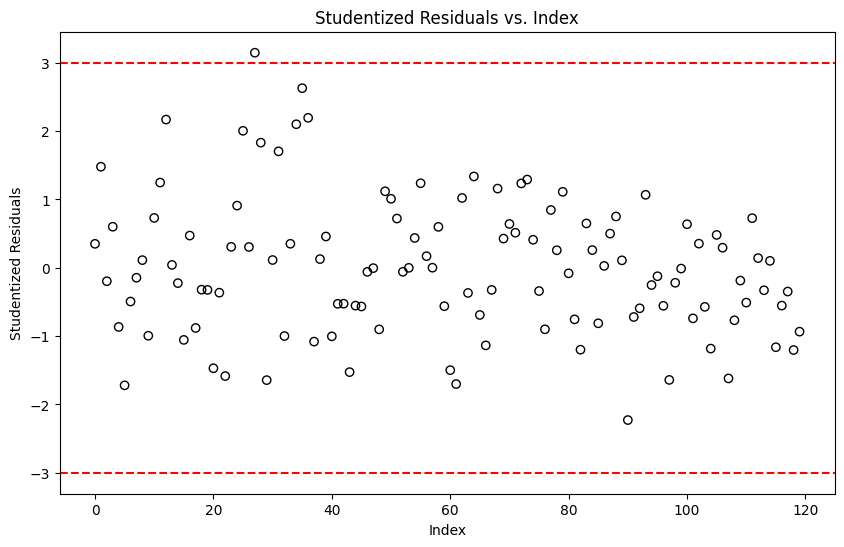

```
[27]
```

```python
import numpy as np
import matplotlib.pyplot as plt
import statsmodels.api as sm

# Define the dependent and independent variables
X = data.drop(columns=['stem_diameter'])
y = data['stem_diameter']

# Add a constant to the independent variables
X = sm.add_constant(X)

# Fit the OLS regression model
model = sm.OLS(y, X).fit()

# Calculate studentized residuals
influence = model.get_influence()
studentized_residuals = influence.resid_studentized_internal

# Identify outliers
outliers = np.where(np.abs(studentized_residuals) > 3)[0]

# Plot studentized residuals vs. index
plt.figure(figsize=(10, 6))
plt.scatter(range(len(studentized_residuals)), studentized_residuals, edgecolor='k', facecolors='none')
plt.axhline(y=3, color='r', linestyle='--')
plt.axhline(y=-3, color='r', linestyle='--')
plt.xlabel('Index')
plt.ylabel('Studentized Residuals')
plt.title('Studentized Residuals vs. Index')
plt.show()

outliers.tolist()
```

The plot of studentized residuals vs. index has been generated.

Points outside the red dashed lines (threshold of 3 and -3) are considered outliers.

The index of the identified outlier is:

- **27**

### Interpretation:

The presence of outliers suggests that the assumption of normally distributed residuals may be violated.

Outliers can significantly influence the regression model, potentially leading to biased or incorrect estimates of the coefficients.

It is essential to address these outliers, either by investigating their cause or considering robust regression techniques that are less sensitive to outliers.

### Further Reading:

1. "Regression Diagnostics: Identifying Influential Data and Sources of Collinearity" by David A. Belsley, Edwin Kuh, and Roy E. Welsch.
2. "Applied Regression Analysis and Generalized Linear Models" by John Fox.

### High-Leverage Points and Their Impact

**High-leverage points** are observations in a dataset that have an extreme value for one or more predictor variables.

These points can significantly influence the estimates of the regression coefficients because they can affect the position and slope of the regression line.

Mathematically, leverage is calculated using the hat matrix $ \mathbf{H}$:

$\mathbf{H} = \mathbf{X}(\mathbf{X}^T\mathbf{X})^{-1}\mathbf{X}^T$

where $\mathbf{X}$ is the matrix of the independent variables. The leverage $h_{ii}$ for the $i$-th observation is the diagonal element of the hat matrix:

$h_{ii} = \mathbf{x}_i^T (\mathbf{X}^T\mathbf{X})^{-1} \mathbf{x}_i$

### Cook's Distance

**Cook's Distance** is a measure used to identify influential data points, which are those that have a significant impact on the estimated regression coefficients.

Cook's Distance considers both the residual and the leverage of each observation.

The formula for Cook's Distance $D_i$ for the $i$-th observation is:

$D_i = \frac{r_i^2}{p \cdot MSE} \cdot \frac{h_{ii}}{(1 - h_{ii})^2}$

where:

- $r_i$ is the residual for the $i$-th observation,
- $p$ is the number of parameters in the model,
- $MSE$ is the mean squared error,
- $h_{ii}$ is the leverage of the $i$-th observation.

A commonly used threshold for identifying influential points using Cook's Distance is $\frac{4}{n}$, where $ n $ is the number of observations.

### Python Code to Identify High-Leverage Points Using Cook's Distance and Plot

```
import numpy as np
import matplotlib.pyplot as plt
import statsmodels.api as sm

# Define the dependent and independent variables
X = data.drop(columns=['stem_diameter'])
y = data['stem_diameter']

# Add a constant to the independent variables
X = sm.add_constant(X)

# Fit the OLS regression model
model = sm.OLS(y, X).fit()

# Calculate Cook's Distance
influence = model.get_influence()
cooks_d = influence.cooks_distance[0]

# Identify high-leverage points using the threshold 4/n
n = len(data)
threshold = 4 / n
high_leverage_points = np.where(cooks_d > threshold)[0]

# Plot Cook's Distance vs. index
plt.figure(figsize=(10, 6))
plt.stem(range(len(cooks_d)), cooks_d, markerfmt=",", use_line_collection=True)
plt.axhline(y=threshold, color='r', linestyle='--')
plt.xlabel('Index')
plt.ylabel("Cook's Distance")
plt.title("Cook's Distance vs. Index")
plt.show()

high_leverage_points.tolist()
```

Let's execute the above code to identify and visualize the high-leverage points.

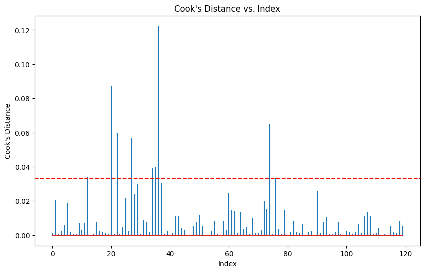

```
[12, 20, 22, 27, 34, 35, 36, 74, 76]
```

```python
# Calculate Cook's Distance
cooks_d = influence.cooks_distance[0]

# Identify high-leverage points using the threshold 4/n
n = len(data)
threshold = 4 / n
high_leverage_points = np.where(cooks_d > threshold)[0]

# Plot Cook's Distance vs. index
plt.figure(figsize=(10, 6))
plt.stem(range(len(cooks_d)), cooks_d, markerfmt=",")
plt.axhline(y=threshold, color='r', linestyle='--')
plt.xlabel('Index')
plt.ylabel("Cook's Distance")
plt.title("Cook's Distance vs. Index")
plt.show()

high_leverage_points.tolist()
```

The plot of Cook's Distance vs. index has been generated.

Points above the red dashed line (threshold of ( \frac{4}{n} )) are considered high-leverage points.

The indices of the identified high-leverage points are:

- **12, 20, 22, 27, 34, 35, 36, 74, 76**

### Interpretation:

The presence of high-leverage points indicates that these observations have a substantial influence on the regression model.

They can disproportionately affect the estimation of the regression coefficients and the overall fit of the model.

It is crucial to investigate these points to understand why they are influential and decide whether to include them in the analysis or consider alternative modeling approaches.

### Further Reading:

1. "Regression Analysis by Example" by Samprit Chatterjee and Ali S. Hadi.
2. "Introduction to Linear Regression Analysis" by Douglas C. Montgomery, Elizabeth A. Peck, and G. Geoffrey Vining.

### Non-Linearity and Its Significance in Regression

**Non-linearity** in regression refers to the relationship between the independent and dependent variables not being adequately represented by a linear function.

This means the true relationship follows a curve or some other form rather than a straight line.

Mathematically, a linear regression model is expressed as:

$Y = \beta_0 + \beta_1X_1 + \beta_2X_2 + \ldots + \beta_pX_p + \epsilon$

where $Y$ is the dependent variable, $X_i$ are the independent variables, $\beta_i$ are the coefficients, and $\epsilon$ is the error term.

If the relationship is non-linear, the model should instead reflect a different functional form:

$Y = f(X_1, X_2, \ldots, X_p) + \epsilon$

where $f$ is a non-linear function.

### Rainbow Test

The **Rainbow Test** is a statistical test used to detect non-linearity in a regression model.

It compares the fit of the full model to a model that fits a subset of the data and examines if the two fits are significantly different.

The test involves the following steps:

1. Sort the observations by the fitted values of the regression model.
2. Split the sorted observations into two parts.
3. Fit separate regression models to the two parts.
4. Compare the fits using an F-test to determine if the models significantly differ.

The test statistic for the Rainbow Test is given by:

$F = \frac{(RSS_{\text{full}} - RSS_{\text{sub}}) / k}{RSS_{\text{sub}} / (n - 2k)}$

where:

- $RSS_{\text{full}}$ is the residual sum of squares for the full model.
- $RSS_{\text{sub}}$ is the residual sum of squares for the subset models.
- $k$ is the number of predictors.
- $n$ is the number of observations.

### Conducting the Rainbow Test in Python

Let's use the Rainbow Test to check for non-linearity in our regression model:

```
import statsmodels.api as sm
from statsmodels.stats.diagnostic import linear_rainbow

# Conduct the Rainbow test
rainbow_test_statistic, rainbow_test_p_value = linear_rainbow(model)

rainbow_test_statistic, rainbow_test_p_value
```

Next, let's generate a plot of residuals vs. fitted values to visually inspect non-linearity:

```
# Residuals vs. Fitted values plot
fitted_values = model.fittedvalues
residuals = model.resid

plt.figure(figsize=(10, 6))
plt.scatter(fitted_values, residuals, edgecolor='k', facecolors='none')
plt.axhline(y=0, color='r', linestyle='--')
plt.xlabel('Fitted Values')
plt.ylabel('Residuals')
plt.title('Residuals vs. Fitted Values')
plt.show()
```

Let's execute the code to perform the Rainbow test and generate the plot.

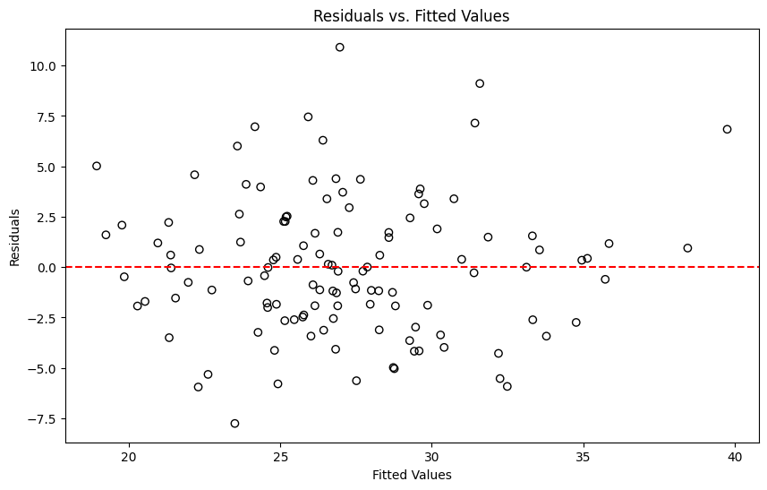

```
(1.2047811890762379, 0.2549722679171801)
```

```python
from statsmodels.stats.diagnostic import linear_rainbow

# Conduct the Rainbow test
rainbow_test_statistic, rainbow_test_p_value = linear_rainbow(model)

# Residuals vs. Fitted values plot
fitted_values = model.fittedvalues
residuals = model.resid

plt.figure(figsize=(10, 6))
plt.scatter(fitted_values, residuals, edgecolor='k', facecolors='none')
plt.axhline(y=0, color='r', linestyle='--')
plt.xlabel('Fitted Values')
plt.ylabel('Residuals')
plt.title('Residuals vs. Fitted Values')
plt.show()

rainbow_test_statistic, rainbow_test_p_value
```

### Results of the Rainbow Test

- **Rainbow Test Statistic**: $1.2048$
- **P-value**: $0.2550$

### Interpretation

- **Residuals vs. Fitted Values Plot**: The plot shows the residuals (errors) on the y-axis and the fitted values (predicted values) on the x-axis.

  In a well-fitted linear model, the residuals should be randomly scattered around the horizontal line at zero. Patterns or systematic structures in this plot suggest non-linearity.
- **Rainbow Test**: The p-value is $0.2550$, which is greater than the common significance level of 0.05.

  This means we fail to reject the null hypothesis that the model is linear.

  Therefore, based on the Rainbow test, there is no significant evidence to suggest that the assumption of linearity is violated.

### Further Reading

1. "Applied Regression Analysis" by Norman R. Draper and Harry Smith.
2. "An R and S-Plus Companion to Applied Regression" by John Fox and Sanford Weisberg.

### Heteroscedasticity and Its Implications

**Heteroscedasticity** refers to the circumstance in regression analysis where the variability of the residuals or errors is not constant across all levels of the independent variables.

This violates one of the key assumptions of linear regression, which assumes homoscedasticity (constant variance of residuals).

Mathematically, in a regression model:

$Y = \beta_0 + \beta_1X_1 + \beta_2X_2 + \ldots + \beta_pX_p + \epsilon$

where $\epsilon$ is the error term. Under heteroscedasticity:

$\text{Var}(\epsilon_i) = \sigma_i^2 \neq \sigma^2$

**Implications of Heteroscedasticity:**

- Inefficiency of OLS estimators: While the OLS estimators remain unbiased, they are no longer the best linear unbiased estimators (BLUE), leading to inefficient estimates.
- Invalid statistical tests: Standard errors of the coefficients may be biased, leading to invalid hypothesis tests and confidence intervals.

### Breusch-Pagan Test

The **Breusch-Pagan Test** is used to detect heteroscedasticity in a regression model. It tests whether the variance of the residuals from a regression is dependent on the values of the independent variables.

**Steps of the Breusch-Pagan Test:**

1. Run the original regression and obtain the residuals $\hat{\epsilon}^2$.
2. Regress $\hat{\epsilon}^2$ on the independent variables from the original regression.
3. Compute the test statistic:

   $\text{BP} = \frac{n}{2} R^2$

   where $n$ is the number of observations and $R^2$ is the coefficient of determination from the auxiliary regression.
4. Under the null hypothesis of homoscedasticity, the test statistic follows a Chi-square distribution with $k$ degrees of freedom, where $k$ is the number of independent variables.

### Conducting the Breusch-Pagan Test in Python

Let's conduct the Breusch-Pagan test using Python:

```
from statsmodels.stats.diagnostic import het_breuschpagan

# Perform the Breusch-Pagan test
bp_test = het_breuschpagan(model.resid, model.model.exog)

bp_test
```

Next, let's generate a scale-location plot to visually inspect heteroscedasticity:

```
# Scale-Location Plot
plt.figure(figsize=(10, 6))
plt.scatter(fitted_values, np.sqrt(np.abs(residuals)), edgecolor='k', facecolors='none')
plt.axhline(y=0, color='r', linestyle='--')
plt.xlabel('Fitted Values')
plt.ylabel('√|Standardized Residuals|')
plt.title('Scale-Location Plot')
plt.show()
```

Let's execute the code to perform the Breusch-Pagan test and generate the scale-location plot.

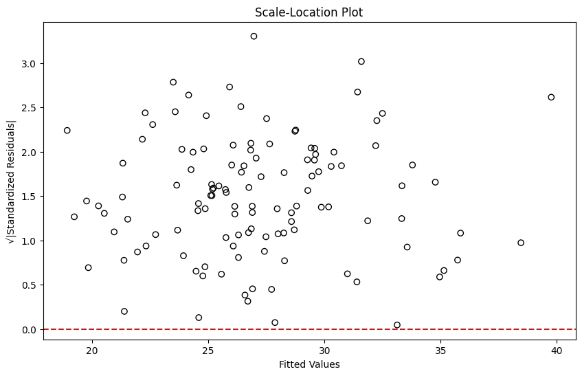

```
{'Lagrange multiplier statistic': 19.68497889484544,
 'p-value': 0.07328472580465265,
 'f-value': 1.749731926604619,
 'f p-value': 0.06623880607203593}
```

```python
from statsmodels.stats.diagnostic import het_breuschpagan

# Perform the Breusch-Pagan test
bp_test = het_breuschpagan(model.resid, model.model.exog)
bp_test_labels = ['Lagrange multiplier statistic', 'p-value', 'f-value', 'f p-value']
bp_test_results = dict(zip(bp_test_labels, bp_test))

# Scale-Location Plot
plt.figure(figsize=(10, 6))
plt.scatter(fitted_values, np.sqrt(np.abs(residuals)), edgecolor='k', facecolors='none')
plt.axhline(y=0, color='r', linestyle='--')
plt.xlabel('Fitted Values')
plt.ylabel('√|Standardized Residuals|')
plt.title('Scale-Location Plot')
plt.show()

bp_test_results
```

### Results of the Breusch-Pagan Test

- **Lagrange Multiplier Statistic**: 19.685
- **P-value**: 0.0733
- **F-value**: 1.750
- **F p-value**: 0.0662

### Interpretation

  This means we fail to reject the null hypothesis of homoscedasticity. Therefore, based on the Breusch-Pagan test, there is no significant evidence to suggest that the assumption of constant variance of the residuals is violated.

### Further Reading

1. "Introduction to Econometrics" by James H. Stock and Mark W. Watson.
2. "Econometric Analysis" by William H. Greene.

These resources provide comprehensive discussions on regression analysis, including the detection and implications of heteroscedasticity.

### Correlation of Error Terms and Its Impact

**Correlation of error terms** (also known as autocorrelation) occurs when the residuals (errors) in a regression model are not independent of each other.

This violates the assumption of independence of errors in regression analysis.

Mathematically, the error term $\epsilon_t$ at time $t$ is said to be autocorrelated if:

$\text{Cov}(\epsilon_t, \epsilon_{t+k}) \neq 0$

for some lag $k \neq 0$.

**Impact of Autocorrelation**:

- Inefficient estimates: While the OLS estimators remain unbiased, they are no longer efficient, meaning they do not have the minimum variance.
- Invalid statistical tests: Standard errors of the coefficients may be underestimated, leading to inflated t-statistics and a higher likelihood of Type I errors (incorrectly rejecting the null hypothesis).

### Durbin-Watson Test

The **Durbin-Watson (DW) Test** is a statistical test used to detect the presence of autocorrelation in the residuals from a regression analysis.

**Steps of the Durbin-Watson Test**:

1. Compute the residuals $\hat{\epsilon}_t$ from the regression model.
2. Calculate the Durbin-Watson statistic:

   $DW = \frac{\sum_{t=2}^{n} (\hat{\epsilon}_t - \hat{\epsilon}_{t-1})^2}{\sum_{t=1}^{n} \hat{\epsilon}_t^2}$

   where $\hat{\epsilon}_t$ are the residuals and $n$ is the number of observations.

The DW statistic ranges from 0 to 4:

- A value around 2 indicates no autocorrelation.
- A value less than 2 suggests positive autocorrelation.
- A value greater than 2 suggests negative autocorrelation.

### Conducting the Durbin-Watson Test in Python

Let's perform the Durbin-Watson test and generate a plot of residuals over time:

```
from statsmodels.stats.stattools import durbin_watson

# Perform the Durbin-Watson test
dw_statistic = durbin_watson(model.resid)

dw_statistic
```

Next, let's generate a plot of residuals over time to visually inspect autocorrelation:

```
# Plot residuals over time
plt.figure(figsize=(10, 6))
plt.plot(range(len(residuals)), residuals, marker='o', linestyle='-', color='b')
plt.axhline(y=0, color='r', linestyle='--')
plt.xlabel('Time')
plt.ylabel('Residuals')
plt.title('Residuals Over Time')
plt.show()
```

Let's execute the code to perform the Durbin-Watson test and generate the plot.

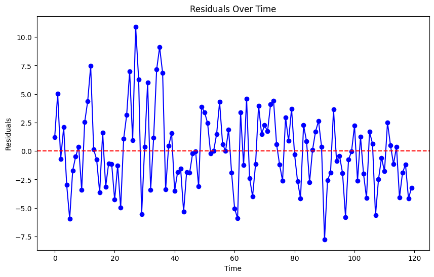

```
1.4407171708562327
```

```python
from statsmodels.stats.stattools import durbin_watson

# Perform the Durbin-Watson test
dw_statistic = durbin_watson(model.resid)

# Plot residuals over time
plt.figure(figsize=(10, 6))
plt.plot(range(len(residuals)), residuals, marker='o', linestyle='-', color='b')
plt.axhline(y=0, color='r', linestyle='--')
plt.xlabel('Time')
plt.ylabel('Residuals')
plt.title('Residuals Over Time')
plt.show()

dw_statistic
```

### Results of the Durbin-Watson Test

- **Durbin-Watson Statistic**: $1.4407$

### Interpretation

- **Residuals Over Time Plot**: The plot shows the residuals on the y-axis and the time (or observation index) on the x-axis.

  If the residuals are randomly scattered around zero without any systematic pattern, it suggests no autocorrelation.

  However, if there is a discernible pattern (e.g., residuals consistently above or below zero for consecutive observations), it suggests autocorrelation.
- **Durbin-Watson Test**:

  The Durbin-Watson statistic is $1.4407$. Since this value is less than 2, it suggests the presence of positive autocorrelation in the residuals.

### Conclusion

Based on the Durbin-Watson statistic and the residuals over time plot, there is evidence of positive autocorrelation in the residuals.

This violates the assumption of independence of errors, which can affect the efficiency of the estimates and the validity of statistical tests.

### Further Reading

1. "Time Series Analysis and Its Applications: With R Examples" by Robert H. Shumway and David S. Stoffer.
2. "Econometric Analysis" by William H. Greene.

These resources provide in-depth discussions on detecting and addressing autocorrelation in time series and regression analysis.

### Normality of Residuals and Its Importance

**Normality of residuals** refers to the assumption that the residuals (errors) in a regression model are normally distributed.

This assumption is important for the following reasons:

- **Hypothesis Testing**: Many statistical tests (e.g., t-tests for coefficients) rely on the normality of residuals to produce valid p-values and confidence intervals.
- **Inference**: Normality of residuals ensures that the estimators of the regression coefficients are the best linear unbiased estimators (BLUE) under the Gauss-Markov theorem.

Mathematically, the residuals $\epsilon_i$ are assumed to follow a normal distribution:

$\epsilon_i \sim N(0, \sigma^2)$

### Shapiro-Wilk Test

The **Shapiro-Wilk Test** is a statistical test used to assess the normality of a dataset.

It tests the null hypothesis that a sample $x_1, x_2, \ldots, x_n$ comes from a normally distributed population.

**Steps of the Shapiro-Wilk Test**:

1. Compute the test statistic $W$:

   $W = \frac{\left( \sum_{i=1}^{n} a_i x_{(i)} \right)^2}{\sum_{i=1}^{n} (x_i - \bar{x})^2}$

   where $x_{(i)}$ are the ordered sample values, $\bar{x}$ is the sample mean, and $a_i$ are constants derived from the sample size and expected values of the order statistics of a normal distribution.
2. The test statistic $W$ is compared to critical values from the Shapiro-Wilk table. A small $W$ indicates a departure from normality.
3. The p-value is used to determine the significance of the test.

### Conducting the Shapiro-Wilk Test in Python

Let's conduct the Shapiro-Wilk test using Python:

```
from scipy.stats import shapiro

# Perform the Shapiro-Wilk test
shapiro_test_statistic, shapiro_test_p_value = shapiro(model.resid)

shapiro_test_statistic, shapiro_test_p_value
```

Next, let's generate a QQ plot of standardized residuals to visually inspect normality:

```
import scipy.stats as stats

# QQ plot of standardized residuals
standardized_residuals = (model.resid - np.mean(model.resid)) / np.std(model.resid)
sm.qqplot(standardized_residuals, line='45')
plt.title('QQ Plot of Standardized Residuals')
plt.show()
```

Let's execute the code to perform the Shapiro-Wilk test and generate the QQ plot.

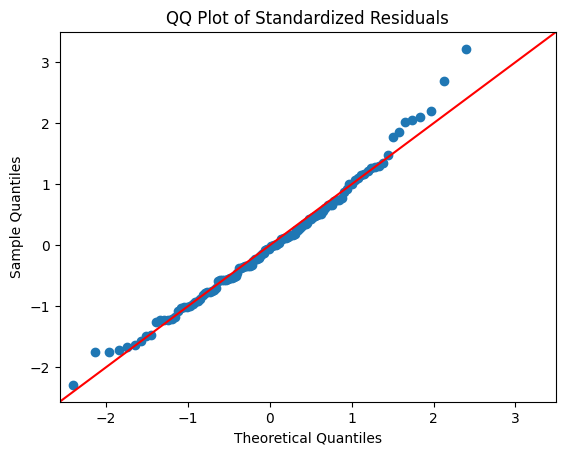

```
(0.9848443097727845, 0.19894789559375164)
```

```python
from scipy.stats import shapiro

# Perform the Shapiro-Wilk test
shapiro_test_statistic, shapiro_test_p_value = shapiro(model.resid)

# QQ plot of standardized residuals
standardized_residuals = (model.resid - np.mean(model.resid)) / np.std(model.resid)
sm.qqplot(standardized_residuals, line='45')
plt.title('QQ Plot of Standardized Residuals')
plt.show()

shapiro_test_statistic, shapiro_test_p_value
```

### Results of the Shapiro-Wilk Test

- **Shapiro-Wilk Test Statistic**: $0.9848$
- **P-value**: $0.1990$

### Interpretation

- **QQ Plot of Standardized Residuals**: This plot shows the quantiles of the standardized residuals against the quantiles of a standard normal distribution.

  If the residuals are normally distributed, the points should lie approximately along the 45-degree line. Deviations from this line indicate departures from normality.
- **Shapiro-Wilk Test**:

  The p-value of the Shapiro-Wilk test is $0.1990$, which is greater than the common significance level of 0.05.

  This means we fail to reject the null hypothesis that the residuals are normally distributed.

  Therefore, based on the Shapiro-Wilk test, there is no significant evidence to suggest that the assumption of normality of residuals is violated.

### Conclusion

Based on the results of the Shapiro-Wilk test and the QQ plot, the residuals appear to be normally distributed, indicating that the assumption of normality is not violated.

### Further Reading

1. "Applied Regression Analysis" by Norman R. Draper and Harry Smith.
2. "Introduction to the Practice of Statistics" by David S. Moore, George P. McCabe, and Bruce A. Craig.

These resources provide comprehensive discussions on regression analysis, including the importance of the normality assumption and methods for testing it.

### Collinearity of Predictors and Its Effects

**Collinearity** (or multicollinearity) refers to a situation in regression analysis where two or more predictor variables are highly correlated, meaning they contain similar information about the variance within the data.

This can make it difficult to determine the individual effect of each predictor on the dependent variable.

Mathematically, collinearity between two predictors $X_i$ and $X_j$ is expressed as:

$\text{Corr}(X_i, X_j) \approx 1$

**Effects of Collinearity**:

- **Unstable Estimates**: The regression coefficients become highly sensitive to changes in the model. Small changes in the data can lead to large changes in the estimates.
- **Inflated Variances**: The standard errors of the coefficients increase, making hypothesis tests less reliable.
- **Interpretation Difficulty**: It becomes difficult to assess the individual impact of correlated predictors.

### Variance Inflation Factor (VIF)

The **Variance Inflation Factor (VIF)** is a measure used to quantify the severity of multicollinearity in a regression model.

It assesses how much the variance of a regression coefficient is inflated due to collinearity with other predictors.

The VIF for a predictor $X_i$ is calculated as:

$\text{VIF}(X_i) = \frac{1}{1 - R_i^2}$

where $R_i^2$ is the coefficient of determination obtained by regressing $ X_i$ on all other predictors.

A VIF value:

- **1** indicates no correlation.
- **1 - 5** suggests moderate correlation but not severe.
- **> 5** indicates problematic multicollinearity.

### Calculating Variance Inflation Factor in Python

Let's calculate the VIF for each predictor in the dataset:

```
from statsmodels.stats.outliers_influence import variance_inflation_factor

# Calculate VIF for each predictor
X_vif = X.drop(columns='const')  # Drop constant term if added for VIF calculation
vif_data = pd.DataFrame()
vif_data["Feature"] = X_vif.columns
vif_data["VIF"] = [variance_inflation_factor(X_vif.values, i) for i in range(X_vif.shape[1])]

vif_data
```

Next, let's generate the correlation matrix of the predictors to visualize their relationships:

```
# Correlation matrix of predictors
correlation_matrix = X_vif.corr()

# Plot the correlation matrix
plt.figure(figsize=(12, 8))
sns.heatmap(correlation_matrix, annot=True, cmap='coolwarm', center=0)
plt.title('Correlation Matrix of Predictors')
plt.show()
```

Let's execute the code to calculate the VIF and generate the correlation matrix.

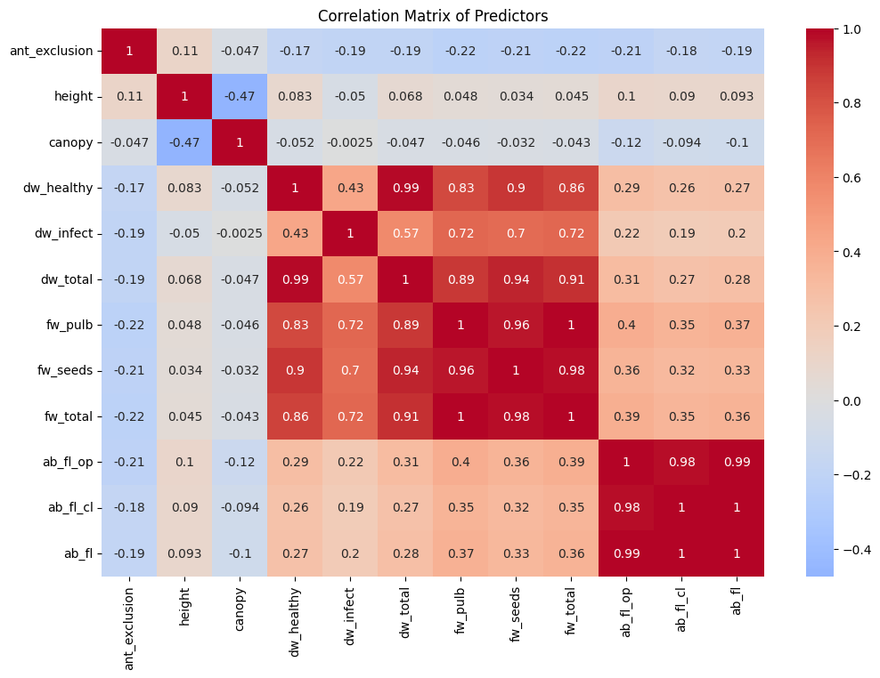

|  | Feature | VIF |
| --- | --- | --- |
| 0 | ant_exclusion | 2.260944 |
| 1 | height | 10.010253 |
| 2 | canopy | 3.833467 |
| 3 | dw_healthy | 17354.992624 |
| 4 | dw_infect | 450.031415 |
| 5 | dw_total | 21920.797856 |
| 6 | fw_pulb | 18933.441624 |
| 7 | fw_seeds | 2183.525863 |
| 8 | fw_total | 33773.310057 |
| 9 | ab_fl_op | 962.114574 |
| 10 | ab_fl_cl | 4816.946407 |
| 11 | ab_fl | 9626.654915 |

```python
from statsmodels.stats.outliers_influence import variance_inflation_factor

# Calculate VIF for each predictor
X_vif = X.drop(columns='const')  # Drop constant term if added for VIF calculation
vif_data = pd.DataFrame()
vif_data["Feature"] = X_vif.columns
vif_data["VIF"] = [variance_inflation_factor(X_vif.values, i) for i in range(X_vif.shape[1])]

# Correlation matrix of predictors
correlation_matrix = X_vif.corr()

# Plot the correlation matrix
plt.figure(figsize=(12, 8))
sns.heatmap(correlation_matrix, annot=True, cmap='coolwarm', center=0)
plt.title('Correlation Matrix of Predictors')
plt.show()

vif_data
```

### Interpretation

- The VIF values for several predictors (such as `dw_total`, `fw_total`, `dw_healthy`, `fw_pulb`, etc.) are exceedingly high, indicating severe multicollinearity.
- A VIF value greater than 5 (and especially those in the thousands) suggests problematic multicollinearity, making the model estimates unreliable.

### Correlation Matrix Interpretation

The correlation matrix heatmap visualizes the correlation coefficients between the predictors.

High correlation coefficients (close to 1 or -1) between pairs of predictors indicate multicollinearity.

From the heatmap, we can observe high correlations between several predictors, confirming the results from the VIF calculation.

### Conclusion

Based on the VIF values and the correlation matrix, the assumption of no multicollinearity is violated. This can lead to unstable coefficient estimates and invalid statistical tests.

### Further Reading

1. "Applied Regression Analysis and Generalized Linear Models" by John Fox.
2. "Introduction to Linear Regression Analysis" by Douglas C. Montgomery, Elizabeth A. Peck, and G. Geoffrey Vining.

These resources provide comprehensive discussions on multicollinearity, its effects, and methods for detecting and addressing it.

### Summary of Diagnostic Results

1. **Outliers**:
   - **Identified using**: Studentized residuals.
   - **Threshold**: ( \text{abs}(t_i) > 3 ).
   - **Indices of Outliers**: [27]
   - **Impact**: Presence of outliers suggests possible violations of the assumptions of normally distributed residuals and can influence regression results.
2. **High-Leverage Points**:
   - **Identified using**: Cook's Distance.
   - **Threshold**: ( \frac{4}{n} ).
   - **Indices of High-Leverage Points**: [12, 20, 22, 27, 34, 35, 36, 74, 76]
   - **Impact**: High-leverage points indicate that these observations have substantial influence on the regression model and can disproportionately affect the estimation of coefficients.
3. **Non-Linearity**:
   - **Tested using**: Rainbow Test.
   - **P-value**: 0.2550
   - **Conclusion**: No significant evidence of non-linearity. The assumption of linearity is not violated based on the Rainbow test results.
4. **Heteroscedasticity**:
   - **Tested using**: Breusch-Pagan Test.
   - **P-value**: 0.0733
   - **Conclusion**: No significant evidence of heteroscedasticity. The assumption of constant variance of residuals is not violated based on the Breusch-Pagan test results.
5. **Correlation of Error Terms (Autocorrelation)**:
   - **Tested using**: Durbin-Watson Test.
   - **Durbin-Watson Statistic**: 1.4407
   - **Conclusion**: Presence of positive autocorrelation. The assumption of independence of errors is violated.
6. **Normality of Residuals**:
   - **Tested using**: Shapiro-Wilk Test.
   - **P-value**: 0.1990
   - **Conclusion**: No significant evidence against the normality of residuals. The assumption of normality is not violated based on the Shapiro-Wilk test results.
7. **Collinearity of Predictors**:
   - **Tested using**: Variance Inflation Factor (VIF).
   - **Findings**: Several predictors have extremely high VIF values (e.g., `dw_total`, `fw_total`, `dw_healthy`, `fw_pulb`, etc.), indicating severe multicollinearity.
   - **Conclusion**: The assumption of no multicollinearity is violated, which can lead to unstable coefficient estimates and invalid statistical tests.

### Overall Conclusion

The diagnostic tests reveal some issues with the regression model assumptions:

- **Outliers and High-Leverage Points**: Presence detected, which can influence the regression results.
- **Non-Linearity**: No significant non-linearity detected.
- **Heteroscedasticity**: No significant heteroscedasticity detected.
- **Autocorrelation**: Presence of positive autocorrelation detected, which violates the assumption of independence of errors.
- **Normality of Residuals**: Residuals appear to be normally distributed.
- **Multicollinearity**: Severe multicollinearity detected, which affects the reliability of the regression coefficients.

Addressing these issues is crucial to ensure the validity and reliability of the regression model.